# Latihan 2 Pertemuan 3

Pemodelan ARDL: Sales (Y) terhadap Advertising (X)

Muhammad Shira Pramudita - NIM M0401241094

03 September 2026

# 1 Pendahuluan

Terdapat data penjualan (*Sales*, $Y_t$) dan biaya iklan (*Advertising*, $X_t$) suatu perusahaan selama 40 tahun (1975-2014). Tugas ini melakukan **pemodelan Autoregressive Distributed Lag (ARDL)** yang sesuai, mengikuti alur praktikum: fit model ARDL awal, cari orde $(p,q)$ optimum, lalu bandingkan untuk **menemukan model terbaik**.

Model ARDL menggabungkan suku autoregresif (lag $Y$) dan lag terdistribusi (lag $X$):
$$Y_t =
\alpha + \phi_1 Y_{t-1} + \dots + \phi_p Y_{t-p} + \beta_0 X_t + \beta_1
X_{t-1} + \dots + \beta_q X_{t-q} + \varepsilon_t$$
Model ini dapat memisahkan respon **jangka pendek** ($\beta_0$) dan **jangka panjang** (total multiplier) dari $Y$ terhadap perubahan $X$.

# 2 Packages

```r
suppressPackageStartupMessages({
  library(dLagM)
  library(nardl)
  library(dynlm)
  library(MLmetrics)
  library(lmtest)
  library(car)
})
```

# 3 Data

```r
data <- data.frame(
  t  = 1:40,
  Yt = c(11.7,12.0,12.3,12.8,13.1,13.6,13.9,14.4,14.7,15.3,
         15.5,15.8,16.1,16.6,16.9,16.7,16.9,17.4,17.6,17.9,
         18.0,17.9,18.0,18.2,18.2,18.3,18.6,19.2,19.3,19.5,
         19.2,19.3,19.5,20.0,20.0,19.9,19.8,19.9,20.2,21.0),
  Xt = c(9.4,9.6,10,10.4,10.8,10.9,11.7,12.2,12.5,12.9,
         13.0,13.2,13.8,14.2,14.6,14.4,15.0,15.4,15.7,15.9,
         15.9,16.0,16.3,16.2,16.8,17.3,17.6,18.1,18.3,18.5,
         18.7,18.9,19.2,20.0,20.0,20.3,20.4,21.0,21.5,22.1)
)
str(data)
```

```
## 'data.frame':    40 obs. of  3 variables:
##  $ t : int  1 2 3 4 5 6 7 8 9 10 ...
##  $ Yt: num  11.7 12 12.3 12.8 13.1 13.6 13.9 14.4 14.7 15.3 ...
##  $ Xt: num  9.4 9.6 10 10.4 10.8 10.9 11.7 12.2 12.5 12.9 ...
```

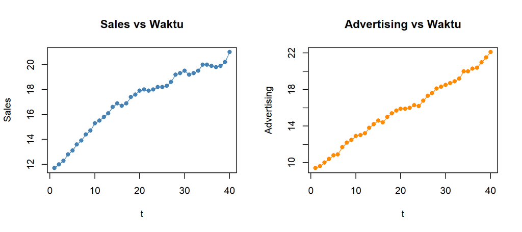

```r
par(mfrow = c(1, 2))
plot(data$t, data$Yt, type = "o", pch = 16, col = "steelblue",
     xlab = "t", ylab = "Sales", main = "Sales vs Waktu")
plot(data$t, data$Xt, type = "o", pch = 16, col = "darkorange",
     xlab = "t", ylab = "Advertising", main = "Advertising vs Waktu")
```

# 4 Pembagian Data

Mengikuti pola praktikum, data dibagi menjadi **data latih** (30 tahun pertama) dan **data uji** (10 tahun terakhir).

```r
train <- data[1:30, ]
test  <- data[31:40, ]
train.ts <- ts(train)
test.ts  <- ts(test)
```

# 5 Model ARDL Awal (p = 1, q = 1)

```r
model.ardl <- ardlDlm(formula = Yt ~ Xt, data = train, p = 1, q = 1)
summary(model.ardl)
```

```
##
## Time series regression with "ts" data:
## Start = 2, End = 30
##
## Call:
## dynlm(formula = as.formula(model.text), data = data)
##
## Residuals:
##       Min        1Q    Median        3Q       Max
## -0.229277 -0.127437  0.009143  0.109228  0.259132
##
## Coefficients:
##             Estimate Std. Error t value Pr(>|t|)
## (Intercept)  1.55786    0.44353   3.512  0.00171 **
## Xt.t         0.29110    0.13707   2.124  0.04376 *
## Xt.1        -0.09584    0.16067  -0.596  0.55621
## Yt.1         0.74360    0.09964   7.463 8.14e-08 ***
## ---
## Signif. codes:  0 '***' 0.001 '**' 0.01 '*' 0.05 '.' 0.1 ' ' 1
##
## Residual standard error: 0.1576 on 25 degrees of freedom
## Multiple R-squared:  0.9955, Adjusted R-squared:  0.9949
## F-statistic:  1830 on 3 and 25 DF,  p-value: < 2.2e-16
```

```r
AIC(model.ardl)
```

```
## [1] -19.18177
```

```r
BIC(model.ardl)
```

```
## [1] -12.34529
```

## 5.1 Peramalan dan Akurasi

```r
fore.ardl <- dLagM::forecast(model = model.ardl, x = test$Xt, h = 10)
fore.ardl
```

```
## $forecasts
##  [1] 19.72862 19.93768 20.16129 20.53170 20.73047 20.96560 21.14081 21.43616
##  [9] 21.74384 22.09937
##
## $call
## forecast.ardlDlm(model = model.ardl, x = test$Xt, h = 10)
##
## attr(,"class")
## [1] "forecast.ardlDlm" "dLagM"
```

```r
mape.ardl <- MAPE(fore.ardl$forecasts, test$Yt)
mape.ardl
```

```
## [1] 0.0484832
```

```r
GoF(model.ardl)
```

|  | n | MAE | MPE | MAPE | sMAPE | MASE | MSE | MRAE | GMRAE |
| --- | --- | --- | --- | --- | --- | --- | --- | --- | --- |
| model.ardl | 29 | 0.1238592 | -0.0001484019 | 0.007696613 | 0.007697173 | 0.4281553 | 0.0214047 | 81884782 | 0.7548444 |

## 5.2 Uji Diagnostik Sisaan

```r
dwtest(model.ardl$model)
```

```
##
##  Durbin-Watson test
##
## data:  model.ardl$model
## DW = 1.9917, p-value = 0.3507
## alternative hypothesis: true autocorrelation is greater than 0
```

```r
bptest(model.ardl$model)
```

```
##
##  studentized Breusch-Pagan test
##
## data:  model.ardl$model
## BP = 0.66214, df = 3, p-value = 0.8821
```

```r
shapiro.test(residuals(model.ardl$model))
```

```
##
##  Shapiro-Wilk normality test
##
## data:  residuals(model.ardl$model)
## W = 0.95502, p-value = 0.2466
```

Sisaan model ARDL(1,1) tidak menunjukkan pelanggaran autokorelasi (DW $\approx 2$, p-value > 0.05), heteroskedastisitas, maupun normalitas (semua p-value > 0.05).

# 6 Pencarian Orde ARDL Optimum

Penentuan orde $(p,q)$ optimum menggunakan `ardlBoundOrders()` berdasarkan kriteria AIC.

```r
model.ardl.opt <- ardlBoundOrders(data = data.frame(train), ic = "AIC", formula = Yt ~ Xt)
model.ardl.opt$p
```

| Xt |
| --- |
| 9 |

```r
model.ardl.opt$q
```

```
## [1] 5
```

```r
model.ardl.opt$min.Stat
```

```
## [1] -52.87776
```

Berdasarkan output tersebut, AIC terkecil (-52.878) didapat pada orde **p = 9, q = 5** — jauh lebih panjang dibanding model awal. Sesuai catatan pada materi kuliah, **AIC cenderung memilih lag yang lebih panjang pada sampel yang relatif kecil**, sehingga orde ini perlu dicek lebih lanjut apakah benar-benar merupakan model yang lebih baik atau hanya overfitting pada data latih.

## 6.1 Pemodelan dengan Orde Optimum

```r
model.ardl.opt.fit <- ardlDlm(formula = Yt ~ Xt, data = train,
                               p = model.ardl.opt$p[1,1], q = model.ardl.opt$q)
summary(model.ardl.opt.fit)
```

```
##
## Time series regression with "ts" data:
## Start = 10, End = 30
##
## Call:
## dynlm(formula = as.formula(model.text), data = data)
##
## Residuals:
##        10        11        12        13        14        15        16        17
## -0.047137 -0.031602  0.113325 -0.032805  0.030371  0.028279 -0.086597 -0.002094
##        18        19        20        21        22        23        24        25
## -0.041602 -0.010191  0.032480  0.075857 -0.002000  0.042920  0.001552 -0.083759
##        26        27        28        29        30
##  0.015217 -0.020501  0.084439  0.022346 -0.088498
##
## Coefficients:
##             Estimate Std. Error t value Pr(>|t|)
## (Intercept)  1.56849    1.45468   1.078   0.3302
## Xt.t         0.34339    0.14187   2.420   0.0601 .
## Xt.1         0.40192    0.25979   1.547   0.1825
## Xt.2         0.29501    0.20367   1.448   0.2072
## Xt.3         0.13653    0.20159   0.677   0.5283
## Xt.4        -0.22909    0.16227  -1.412   0.2171
## Xt.5         0.25194    0.18270   1.379   0.2264
## Xt.6         0.04751    0.21147   0.225   0.8311
## Xt.7        -0.03322    0.18131  -0.183   0.8618
## Xt.8        -0.35324    0.17807  -1.984   0.1041
## Xt.9        -0.31656    0.27847  -1.137   0.3072
## Yt.1         0.05843    0.39822   0.147   0.8891
## Yt.2        -0.32406    0.26349  -1.230   0.2735
## Yt.3         0.47154    0.28751   1.640   0.1619
## Yt.4         0.33879    0.33335   1.016   0.3561
## Yt.5        -0.17135    0.23147  -0.740   0.4924
## ---
## Signif. codes:  0 '***' 0.001 '**' 0.01 '*' 0.05 '.' 0.1 ' ' 1
##
## Residual standard error: 0.1095 on 5 degrees of freedom
## Multiple R-squared:  0.998,  Adjusted R-squared:  0.9919
## F-statistic: 164.4 on 15 and 5 DF,  p-value: 1.064e-05
```

```r
AIC(model.ardl.opt.fit)
```

```
## [1] -29.4262
```

```r
BIC(model.ardl.opt.fit)
```

```
## [1] -11.66932
```

Terlihat bahwa **hampir seluruh koefisien lag tidak signifikan** (p-value > 0.05) dan derajat bebas sisaan sangat kecil — ciri khas model yang terlalu kompleks (overfitting) untuk ukuran data latih yang ada.

## 6.2 Peramalan dan Akurasi

```r
fore.ardl.opt <- dLagM::forecast(model = model.ardl.opt.fit, x = test$Xt, h = 10)
mape.ardl.opt <- MAPE(fore.ardl.opt$forecasts, test$Yt)
mape.ardl.opt
```

```
## [1] 0.0732169
```

# 7 Perbandingan Model & Model Terbaik

```r
akurasi <- matrix(c(mape.ardl, mape.ardl.opt))
row.names(akurasi) <- c(paste0("ARDL (p=1, q=1)"),
                         paste0("ARDL (p=", model.ardl.opt$p[1,1], ", q=", model.ardl.opt$q, ") - optimum AIC"))
colnames(akurasi) <- "MAPE"
akurasi
```

```
##                                    MAPE
## ARDL (p=1, q=1)               0.0484832
## ARDL (p=9, q=5) - optimum AIC 0.0732169
```

Meskipun model dengan orde optimum-AIC memiliki AIC pelatihan yang jauh lebih rendah, nilai **MAPE pada data uji justru lebih besar** (0.0732 vs 0.0485) — mengonfirmasi bahwa model tersebut **overfit** terhadap data latih. Berdasarkan akurasi ramalan pada data uji, model terbaik adalah **ARDL (p=1, q=1)**.

## 7.1 Plot Perbandingan Ramalan

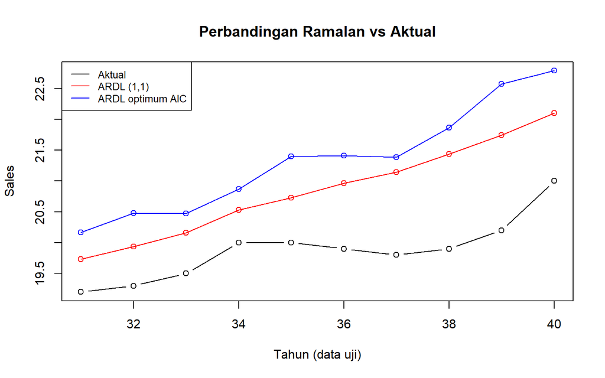

```r
plot(test$t, test$Yt, type = "b", col = "black",
     ylim = range(c(test$Yt, fore.ardl$forecasts, fore.ardl.opt$forecasts)),
     xlab = "Tahun (data uji)", ylab = "Sales", main = "Perbandingan Ramalan vs Aktual")
points(test$t, fore.ardl$forecasts, col = "red"); lines(test$t, fore.ardl$forecasts, col = "red")
points(test$t, fore.ardl.opt$forecasts, col = "blue"); lines(test$t, fore.ardl.opt$forecasts, col = "blue")
legend("topleft", c("Aktual", "ARDL (1,1)", "ARDL optimum AIC"),
       lty = 1, col = c("black", "red", "blue"), cex = 0.8)
```

# 8 Kesimpulan

```
## (Intercept)        Xt.t        Xt.1        Yt.1
##  1.55786420  0.29110337 -0.09583802  0.74359628
```

Model **ARDL(p=1, q=1)** dipilih sebagai model terbaik, dengan persamaan dugaan:

$$\hat{Y}_t = 1.5579 +0.2911 X_t -0.0958
X_{t-1} +0.7436 Y_{t-1}$$

**Interpretasi:**

- **Dampak jangka pendek/impact multiplier** ($\beta_0 = 0.2911$, signifikan): kenaikan biaya iklan sebesar 1 satuan pada periode ini diasosiasikan dengan kenaikan penjualan sebesar 0.2911 satuan pada periode yang sama.
- **Koefisien $Y_{t-1}$** ($\phi_1 = 0.7436$, signifikan): sekitar 74.4% dari level penjualan periode lalu terbawa ke periode ini, menunjukkan penjualan memiliki inersia/persistensi yang kuat.
- **Dampak jangka panjang / total multiplier**:
  $$\frac{\beta_0+\beta_1}{1-\phi_1} =
  \frac{0.2911+(-0.0958)}{1-0.7436} = 0.7616$$
  Jika kenaikan biaya iklan sebesar 1 satuan dipertahankan secara permanen, total kenaikan penjualan dalam jangka panjang adalah sekitar 0.7616 satuan.
- Model ini dipilih di atas model dengan orde AIC-optimum ($p=9, q=5$) karena performa ramalan pada data uji **jauh lebih baik** (MAPE 0.0485 vs 0.0732), sekaligus **lebih sederhana** (parsimoni) dan **seluruh sisaannya memenuhi asumsi klasik** (non-autokorelasi, homoskedastisitas, normalitas) — sedangkan model orde tinggi tersebut overfit terhadap data latih.